# 31 ICE: Extract register data

Author

Affiliation

Vladimir Buskin

Catholic University of Eichstätt-Ingolstadt

## 31.1 Preparation

This supplementary unit illustrates how to extract register information from `kwic()` queries performed on data from the International Corpus of English (cf. Concordancing). We begin by loading the relevant libraries:

```r
library(tidyverse)
library(readxl)
```

Next we load some sample data to work with. If you have data of your own, you may skip this step.

```r
# Load data
data_eat <- read_xlsx("eat_obj_aspect.xlsx")
```

The dataset follows the default `kwic()` structure with the document name and the immediate context before and after the keyword. The columns `object_realisation` (dependent variable) and `verb_aspect` (indepdent variable) are the result of manual annotation in Microsoft Excel.

```r
# First few lines
head(data_eat)
```

```
# A tibble: 6 × 9
  docname  from    to pre   keyword post  pattern object_realisation verb_aspect
  <chr>   <dbl> <dbl> <chr> <chr>   <chr> <chr>   <chr>              <chr>
1 ICE_GB…   458   458 had … eaten   anyw… "\\b(e… no                 perfective
2 ICE_GB…   478   478 : 1 … eating  will… "\\b(e… no                 progressive
3 ICE_GB…   785   785 > Ye… eat     befo… "\\b(e… no                 neutral
4 ICE_GB…  1198  1198 the … eat     them… "\\b(e… yes                neutral
5 ICE_GB…  4529  4529 > Ye… ate     in t… "\\b(e… no                 neutral
6 ICE_GB…   958   958 know… eat     it f… "\\b(e… yes                neutral
```

## 31.2 Fine-grained: Text categories

After querying the ICE corpora, information on the texts (and, therefore, the register) is stored in the `docname` column.

```r
head(data_eat[,"docname"])
```

```
# A tibble: 6 × 1
  docname
  <chr>
1 ICE_GB/S1A-006.txt
2 ICE_GB/S1A-006.txt
3 ICE_GB/S1A-006.txt
4 ICE_GB/S1A-009.txt
5 ICE_GB/S1A-009.txt
6 ICE_GB/S1A-010.txt
```

We want to split up this column into two separate ones. One should contain the text category labels (S1A, S1B, S2A etc.) and one the file numbers (001, 002, 003 etc.). The tidyverse function `seperate_wider_delim()` offers a method to handle that. Let’s call the new columns `text_category` and `file_number`, respectively.

If you apply the function to your own data, simply exchange the `data =` argument with your search results, and leave the rest as is.

```r
data_eat_reg <- separate_wider_delim(
                                # Original data frame
                                data = data_eat,
                                # Which column to split
                                cols = docname,
                                # Where to split it (at the hypen)
                                delim = "-", # where to split exactly
                                # Names of the new columns
                                names = c("text_category", "file_number")
                                )
```

The query results now have the desired format:

```r
head(data_eat_reg)
```

```
# A tibble: 6 × 10
  text_category file_number  from    to pre                keyword post  pattern
  <chr>         <chr>       <dbl> <dbl> <chr>              <chr>   <chr> <chr>
1 ICE_GB/S1A    006.txt       458   458 had lunch < ICE-G… eaten   anyw… "\\b(e…
2 ICE_GB/S1A    006.txt       478   478 : 1 : A > Well I … eating  will… "\\b(e…
3 ICE_GB/S1A    006.txt       785   785 > Yeah < ICE-GB:S… eat     befo… "\\b(e…
4 ICE_GB/S1A    009.txt      1198  1198 the summer < ICE-… eat     them… "\\b(e…
5 ICE_GB/S1A    009.txt      4529  4529 > Yeah < , > < IC… ate     in t… "\\b(e…
6 ICE_GB/S1A    010.txt       958   958 know I mean it wo… eat     it f… "\\b(e…
# ℹ 2 more variables: object_realisation <chr>, verb_aspect <chr>
```

It is now possible to investigate associations between register (i.e., `text_category`) and other variables more comfortably.

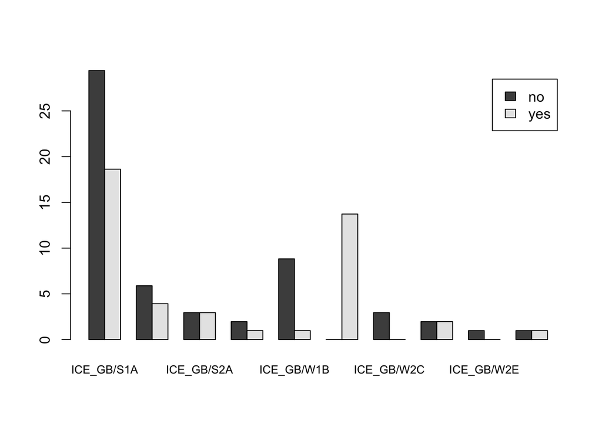

```r
# Cross-tabulate "text_category" and "keyword"
obj_reg_freq <- xtabs(~ object_realisation + text_category, data_eat_reg)

object_reg_prop <- prop.table(obj_reg_freq) * 100

# Simple barplot
barplot(object_reg_prop,
        beside = TRUE,
        legend = TRUE,
        cex.names = 0.8)
```

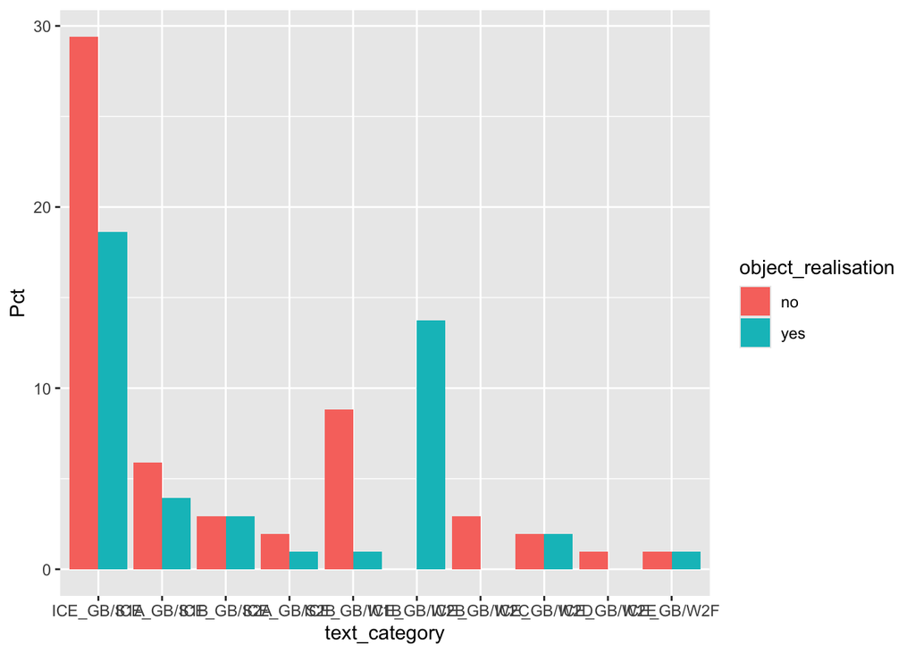

```r
# Fancy plot with ggplot2 (requires tidyverse)

# Convert to data frame
obj_reg_df <- as.data.frame(object_reg_prop)

# Rename "Freq" column to "Pct"
obj_reg_df <- rename(obj_reg_df, Pct = Freq)

# Pass it to the plotting function
ggplot(obj_reg_df, aes(x = text_category, y = Pct, fill = object_realisation)) +
  geom_col(position = "dodge")
```

```r
# Statistical analysis
chisq.test(data_eat_reg$object_realisation, data_eat_reg$text_category)
```

```
    Pearson's Chi-squared test

data:  data_eat_reg$object_realisation and data_eat_reg$text_category
X-squared = 26.559, df = 9, p-value = 0.001654
```

## 31.3 Spoken vs. written